# What Drives Healthcare Costs? A Statistical Analysis for Public Health Policy

Michael Matyevich

2026-04-10

## Background

Healthcare costs are rising in most developed countries, placing increasing strain on public health systems and insurers alike. Understanding *which patient characteristics most strongly predict higher costs* is critical for designing effective public health interventions — particularly when resources are limited and policy decisions need to be evidence-based.

This analysis uses a dataset of 1,338 US insurance beneficiaries to answer three research questions.

## Research Questions

**RQ1 — What patient characteristics are most strongly associated with higher insurance charges?**

We expect age, BMI, and smoking status to be important based on the clinical literature, but the relative magnitude of each, and whether they *interact* with one another, is not known in advance. Understanding this helps prioritise which risk factors are most impactful to address.

**RQ2 — Does the effect of BMI on charges depend on whether a person smokes?**

If the relationship between BMI and cost is *steeper* for smokers than non-smokers, that would suggest that smoking and obesity compound each other — meaning a policy targeting both simultaneously would be more cost-effective than targeting either alone.

**RQ3 — Which modelling approach best predicts individual insurance charges?**

We compare four methods: linear regression, regression trees, random forests, and XGBoost. A more accurate predictive model helps insurers and health planners identify high-risk individuals earlier, enabling earlier intervention.

## Dataset Description

The dataset contains **1,338 rows** and **7 variables** representing US health insurance beneficiaries. Each row is one individual. The outcome variable is `charges` — the annual medical cost billed by the insurer in USD.

| Variable | Type | Description |
| --- | --- | --- |
| age | Numeric | Age of the beneficiary in years |
| sex | Categorical | Male or female |
| bmi | Numeric | Body Mass Index (weight/height²) |
| children | Numeric | Number of dependants covered |
| smoker | Categorical | Whether the person currently smokes |
| region | Categorical | US geographic region (NE, NW, SE, SW) |
| charges | Numeric | Annual medical charges billed (USD) — **outcome** |

The dataset contains **no missing values**, so no imputation was required.

## Exploratory Analysis

Before building any models, we examine the data to understand its structure and identify any patterns worth investigating further.

```r
str(med_df)
```

```
## 'data.frame':    1338 obs. of  8 variables:
##  $ age     : int  19 18 28 33 32 31 46 37 37 60 ...
##  $ sex     : Factor w/ 2 levels "female","male": 1 2 2 2 2 1 1 1 2 1 ...
##  $ bmi     : num  27.9 33.8 33 22.7 28.9 ...
##  $ children: int  0 1 3 0 0 0 1 3 2 0 ...
##  $ smoker  : Factor w/ 2 levels "no","yes": 2 1 1 1 1 1 1 1 1 1 ...
##  $ region  : Factor w/ 4 levels "northeast","northwest",..: 4 3 3 2 2 3 3 2 1 2 ...
##  $ charges : num  16885 1726 4449 21984 3867 ...
##  $ bmi_cat : Factor w/ 4 levels "Underweight",..: 3 4 4 2 3 3 4 3 3 3 ...
```

```r
summary(med_df)
```

```
##       age            sex           bmi           children     smoker
##  Min.   :18.00   female:662   Min.   :15.96   Min.   :0.000   no :1064
##  1st Qu.:27.00   male  :676   1st Qu.:26.30   1st Qu.:0.000   yes: 274
##  Median :39.00                Median :30.40   Median :1.000
##  Mean   :39.21                Mean   :30.66   Mean   :1.095
##  3rd Qu.:51.00                3rd Qu.:34.69   3rd Qu.:2.000
##  Max.   :64.00                Max.   :53.13   Max.   :5.000
##        region       charges             bmi_cat
##  northeast:324   Min.   : 1122   Underweight: 20
##  northwest:325   1st Qu.: 4740   Normal     :225
##  southeast:364   Median : 9382   Overweight :386
##  southwest:325   Mean   :13270   Obese      :707
##                  3rd Qu.:16640
##                  Max.   :63770
```

```r
colSums(is.na(med_df))
```

```
##      age      sex      bmi children   smoker   region  charges  bmi_cat
##        0        0        0        0        0        0        0        0
```

### Distribution of charges

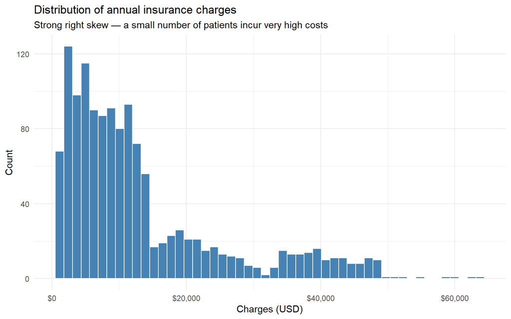

```r
ggplot(med_df, aes(charges)) +
  geom_histogram(bins = 50, fill = "steelblue", colour = "white") +
  scale_x_continuous(labels = dollar_format()) +
  labs(title = "Distribution of annual insurance charges",
       subtitle = "Strong right skew — a small number of patients incur very high costs",
       x = "Charges (USD)", y = "Count") +
  theme_minimal()
```

The distribution of charges is strongly **right-skewed**: most people incur relatively modest costs, but a small number of patients generate very high charges. This skew is common in healthcare cost data and is worth noting because it means the *average* charge is pulled upward by a few extreme cases — the *median* is a more representative summary of what a typical patient costs.

From a statistical standpoint, this skew also violates the normality assumption that linear regression relies on for valid p-values and confidence intervals. We test a log-transformation below to see if it improves the distribution.

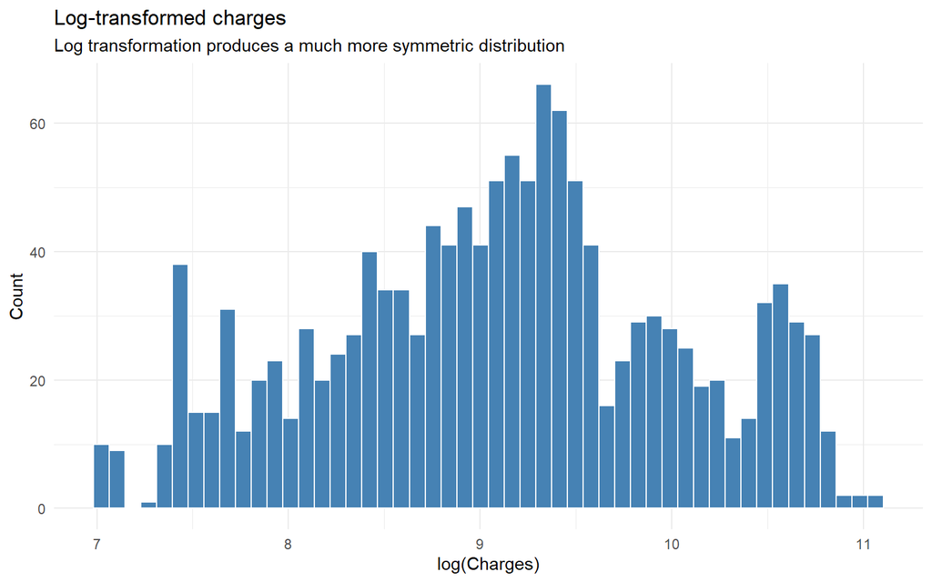

```r
ggplot(med_df, aes(log(charges))) +
  geom_histogram(bins = 50, fill = "steelblue", colour = "white") +
  labs(title = "Log-transformed charges",
       subtitle = "Log transformation produces a much more symmetric distribution",
       x = "log(Charges)", y = "Count") +
  theme_minimal()
```

The log-transformed distribution is substantially more symmetric, which is useful to know — it means if we want reliable inference (trustworthy p-values and confidence intervals) from linear regression, modelling log(charges) rather than charges directly would be the more rigorous approach. We retain the original scale here for interpretability, but flag this as a limitation when reviewing the linear model diagnostics.

### Correlations between numeric predictors and charges

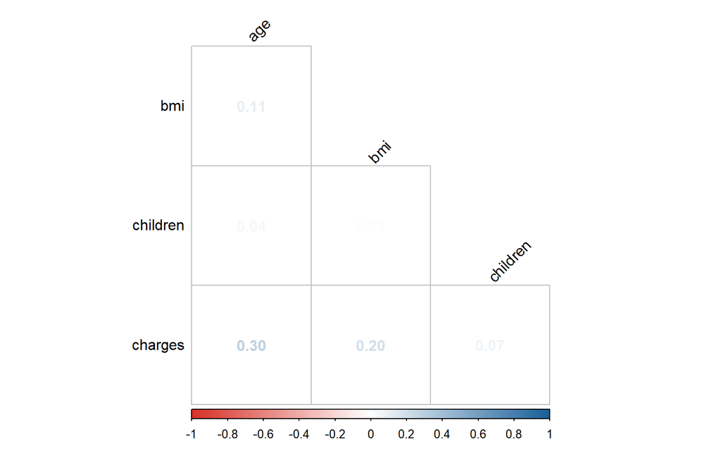

```r
med_cor <- med_df |> select(age, bmi, children, charges)
corrplot(cor(med_cor),
         method   = 'number',
         type     = 'lower',
         diag     = FALSE,
         col      = colorRampPalette(c("#D73027", "white", "#1A6099"))(200),
         tl.col   = 'black',
         tl.srt   = 45)
```

Among the numeric variables, **age has the strongest correlation with charges (r = 0.30)**, followed by BMI (r = 0.20). The number of children is essentially unrelated to cost (r = 0.07).

However, correlation only captures *linear* relationships between two variables at a time — it does not tell us how variables interact with one another, or how much each predictor contributes once others are held constant. That requires regression modelling.

### Charges by categorical predictors

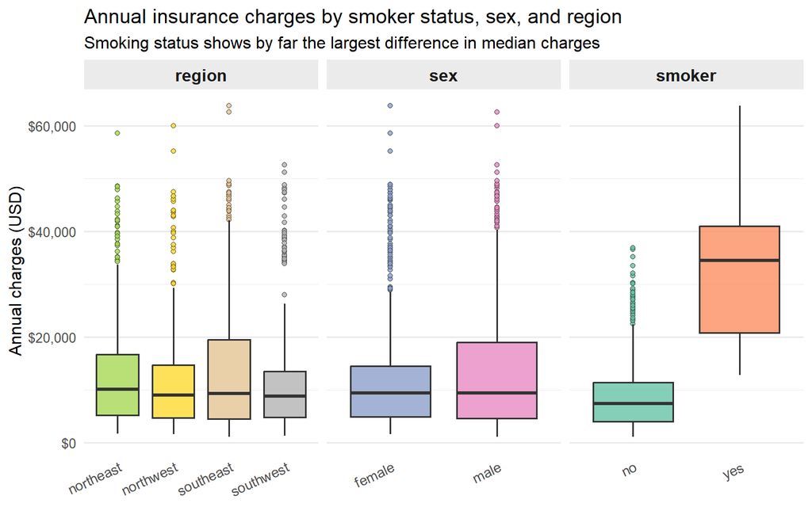

```r
med_df |>
  pivot_longer(cols = c(smoker, sex, region),
               names_to  = "variable",
               values_to = "category") |>
  ggplot(aes(x = category, y = charges, fill = category)) +
  geom_boxplot(outlier.shape = 21, outlier.size = 1.5, alpha = 0.8) +
  facet_wrap(~ variable, scales = "free_x") +
  scale_y_continuous(labels = dollar_format()) +
  scale_fill_brewer(palette = "Set2") +
  labs(title = "Annual insurance charges by smoker status, sex, and region",
       subtitle = "Smoking status shows by far the largest difference in median charges",
       x = NULL, y = "Annual charges (USD)") +
  theme_minimal(base_size = 12) +
  theme(
    legend.position    = "none",
    strip.text         = element_text(face = "bold", size = 12),
    strip.background   = element_rect(fill = "grey92", colour = NA),
    axis.text.x        = element_text(angle = 25, hjust = 1),
    panel.grid.major.x = element_blank()
  )
```

### Does the effect of BMI differ by smoking status?

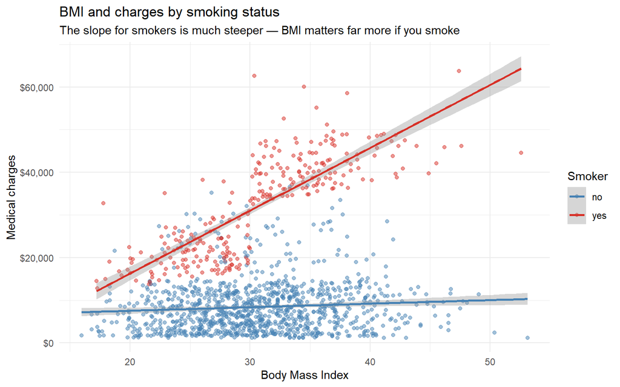

```r
ggplot(med_df, aes(x = bmi, y = charges, col = smoker)) +
  geom_point(alpha = 0.5) +
  geom_smooth(method = 'lm') +
  scale_y_continuous(labels = dollar_format()) +
  scale_colour_manual(values = c("no" = "steelblue", "yes" = "#D73027")) +
  labs(x = "Body Mass Index", y = "Medical charges",
       title = "BMI and charges by smoking status",
       subtitle = "The slope for smokers is much steeper — BMI matters far more if you smoke",
       colour = "Smoker") +
  theme_minimal()
```

This plot directly addresses RQ2. The two trend lines have **very different slopes**:

- For **non-smokers** (blue), the BMI-charges relationship is almost flat — BMI has little independent effect on cost for people who do not smoke.
- For **smokers** (red), the slope is steep — each additional BMI unit is associated with substantially higher charges.

This divergence is the statistical definition of an **interaction effect**: the impact of one variable (BMI) depends on the value of another (smoking status). This means any model that treats BMI and smoking as independent predictors will misrepresent how costs actually accumulate. We formally test and include this interaction term in the linear regression.

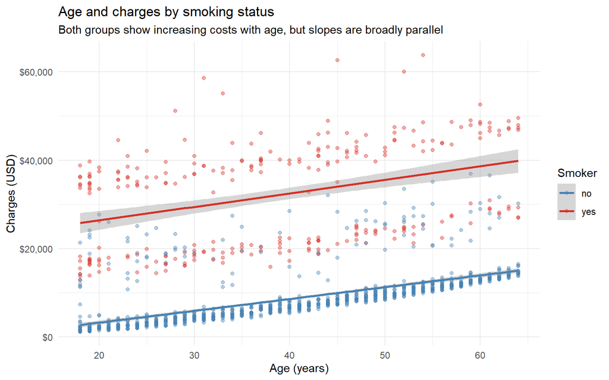

```r
ggplot(med_df, aes(x = age, y = charges, col = smoker)) +
  geom_point(alpha = 0.4) +
  geom_smooth(method = 'lm') +
  scale_y_continuous(labels = dollar_format()) +
  scale_colour_manual(values = c("no" = "steelblue", "yes" = "#D73027")) +
  labs(title = "Age and charges by smoking status",
       subtitle = "Both groups show increasing costs with age, but slopes are broadly parallel",
       x = "Age (years)", y = "Charges (USD)", colour = "Smoker") +
  theme_minimal()
```

Unlike the BMI plot, the age-charges slopes for smokers and non-smokers are roughly **parallel** — age increases costs at a similar rate regardless of smoking status. This suggests an age × smoking interaction is less warranted. Both groups do show a steady increase with age, consistent with older patients having more cumulative health needs.

## Risk Modelling

We split the data into a **training set (80%, n ≈ 1,070)** used to build models, and a **test set (20%, n ≈ 268)** held back to evaluate how well each model generalises to new data. This separation is essential — evaluating a model on the same data it was trained on produces an overly optimistic picture of real-world performance.

```r
set.seed(100)
train_index <- createDataPartition(med_df$charges, p = 0.8, list = FALSE)
train <- med_df[train_index, ]
test  <- med_df[-train_index, ]
```

### Linear Regression

Linear regression estimates the independent contribution of each predictor to charges, holding all other variables constant. It produces interpretable coefficients — each coefficient tells us the expected change in annual charges for a one-unit increase in that variable.

We fit two models: one with main effects only, and one that adds the BMI × smoking interaction identified in the exploratory analysis.

```r
lm_model <- lm(charges ~ age + sex + bmi + children + smoker + region,
               data = train)

lm_int_model <- lm(charges ~ age + sex + bmi + children + smoker + region +
                     smoker:bmi,
                   data = train)

tidy(lm_int_model, conf.int = TRUE) |>
  mutate(across(where(is.numeric), ~ round(.x, 2))) |>
  print()
```

```
## # A tibble: 10 × 7
##    term            estimate std.error statistic p.value conf.low conf.high
##    <chr>              <dbl>     <dbl>     <dbl>   <dbl>    <dbl>     <dbl>
##  1 (Intercept)      -2250.     1002.      -2.25    0.02  -4215.     -284.
##  2 age                267.       10.9     24.4     0       245.      288.
##  3 sexmale           -641.      307.      -2.09    0.04  -1242.      -39.2
##  4 bmi                 18.2      29.5      0.61    0.54    -39.8      76.1
##  5 children           525.      127.       4.13    0       276.      774.
##  6 smokeryes       -21297.     1964.     -10.8     0    -25151.   -17444.
##  7 regionnorthwest   -291.      436.      -0.67    0.5   -1146.      564.
##  8 regionsoutheast   -948.      445.      -2.13    0.03  -1822.      -75.0
##  9 regionsouthwest   -941.      441.      -2.13    0.03  -1807.      -75.9
## 10 bmi:smokeryes     1460.       62.1     23.5     0      1339.     1582.
```

#### Is the interaction term worth including?

```r
anova(lm_model, lm_int_model)
```

|  | Res.Df | RSS | Df | Sum of Sq | F | Pr(>F) |
| --- | --- | --- | --- | --- | --- | --- |
| 1 | 1063 | 40234524438 | NA | NA | NA | NA |
| 2 | 1062 | 26463144700 | 1 | 13771379738 | 552.6632 | 1.003263e-98 |

The ANOVA F-test compares the two models directly. The result (F = 552, p < 2.2e-16) is overwhelmingly significant — the interaction term explains a large additional portion of the variance in charges. **Including it is clearly justified.**

The F-statistic of 552 is very large by any standard; a value above ~4 would typically be considered significant. A value this large means the improvement from adding the interaction term is almost certainly not due to chance.

#### Coefficient plot

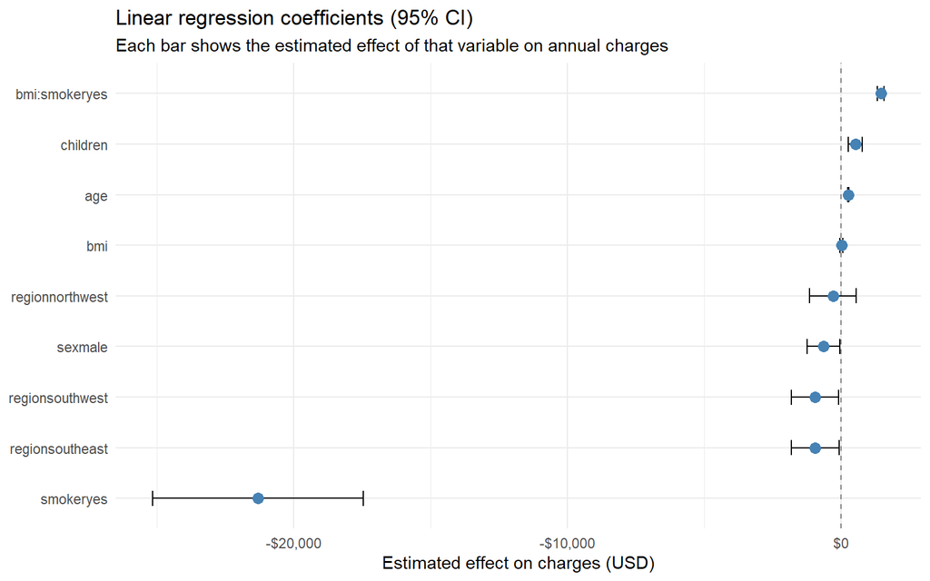

```r
tidy(lm_int_model, conf.int = TRUE) |>
  filter(term != "(Intercept)") |>
  ggplot(aes(x = estimate, y = reorder(term, estimate))) +
  geom_vline(xintercept = 0, linetype = "dashed", colour = "grey50") +
  geom_errorbarh(aes(xmin = conf.low, xmax = conf.high), height = 0.3) +
  geom_point(size = 3, colour = "steelblue") +
  scale_x_continuous(labels = dollar_format()) +
  labs(title = "Linear regression coefficients (95% CI)",
       subtitle = "Each bar shows the estimated effect of that variable on annual charges",
       x = "Estimated effect on charges (USD)", y = NULL) +
  theme_minimal()
```

#### What does smoking actually cost at a typical BMI?

```r
mean_bmi <- mean(train$bmi)
coefs    <- coef(lm_int_model)

smoking_effect_at_mean_bmi <- coefs["smokeryes"] +
                               coefs["bmi:smokeryes"] * mean_bmi

cat("At the average BMI of", round(mean_bmi, 1),
    "— a smoker is estimated to pay an additional",
    dollar(round(smoking_effect_at_mean_bmi, 0)),
    "per year in insurance charges compared to a non-smoker with the same characteristics.")
```

```
## At the average BMI of 30.7 — a smoker is estimated to pay an additional $23,601 per year in insurance charges compared to a non-smoker with the same characteristics.
```

This is the most policy-relevant number in the linear model. It translates the abstract coefficient into a concrete dollar figure that a public health planner can act on. An individual who quits smoking could expect to save roughly this amount annually in medical costs — and the savings are even larger at higher BMI values.

#### Checking model assumptions

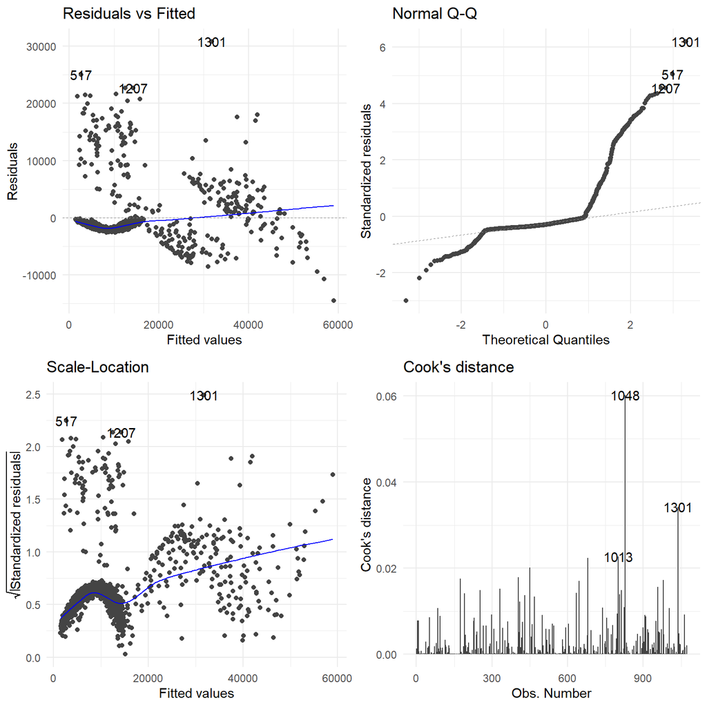

```r
autoplot(lm_int_model, which = 1:4, ncol = 2) + theme_minimal()
```

These four diagnostic plots reveal some important limitations of the linear model:

- **Residuals vs Fitted** (top left): The residuals fan outward as fitted values increase — a pattern called *heteroscedasticity*. This means the model’s errors are larger for high-cost patients than low-cost ones. The consequence is that our standard errors, and therefore our p-values and confidence intervals, are not fully reliable.
- **Normal Q-Q** (top right): Points in the upper tail deviate from the diagonal line, indicating the residuals are more right-skewed than a normal distribution assumes. This reinforces the concern above.
- **Scale-Location** (bottom left): The upward trend confirms heteroscedasticity formally.
- **Cook’s Distance** (bottom right): A small number of observations (notably #1048 and #1301) have high influence on the model’s estimates. These are likely patients with unusually high charges who are pulling the fitted line toward them.

**The practical takeaway**: the linear model’s coefficient estimates are useful for understanding direction and approximate magnitude of effects, but the exact p-values and confidence intervals should be interpreted with caution. The tree-based models below do not make these distributional assumptions and are therefore less sensitive to these issues.

```r
lm_pred     <- predict(lm_model, test)
lm_pred_int <- predict(lm_int_model, test)
rmse_lm     <- rmse(test$charges, lm_pred)
rmse_lm_int <- rmse(test$charges, lm_pred_int)
```

### Regression Tree

A regression tree makes predictions by splitting the data into groups based on simple yes/no rules (e.g. “is the person a smoker? is their BMI above 30?”). The result is a flowchart-like structure that is highly interpretable — you can trace any individual’s predicted cost through the branches. The trade-off is that a single tree tends to be less accurate than more complex ensemble methods.

The **complexity parameter (cp)** controls how deeply the tree grows. A tree that grows too deep will memorise the training data but predict poorly on new patients (overfitting). We use the cp plot to prune to the optimal depth.

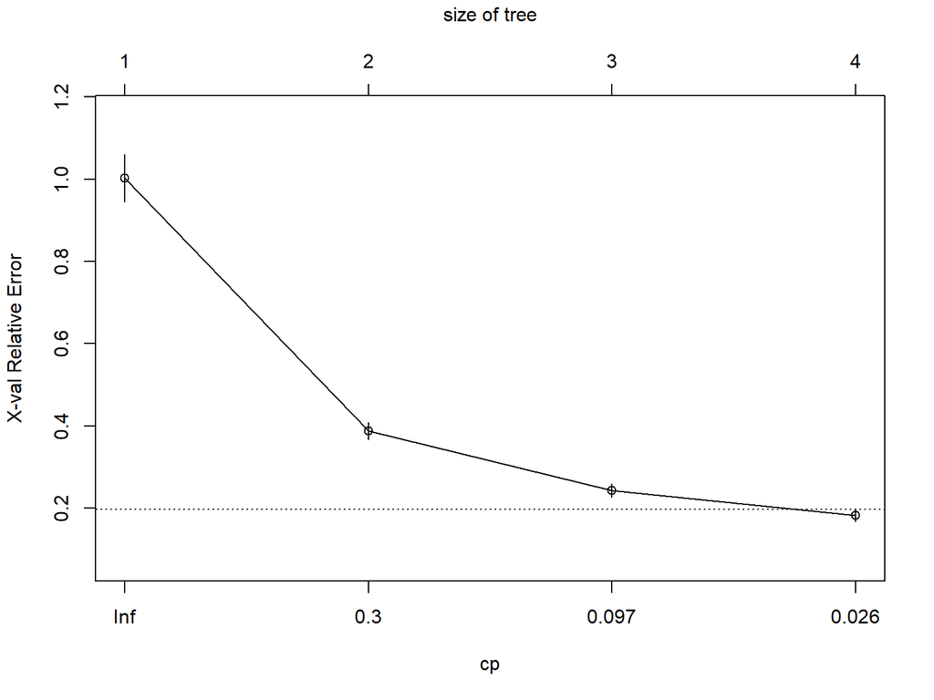

```r
tree_model <- rpart(charges ~ ., data = train, method = "anova",
                    control = rpart.control(cp = 0.01))

plotcp(tree_model)
```

The cp plot shows prediction error (cross-validated) on the y-axis against tree complexity on the x-axis. We select the simplest tree whose error is within 1 standard error of the minimum — the convention is to pick the leftmost point that falls under the horizontal dashed line.

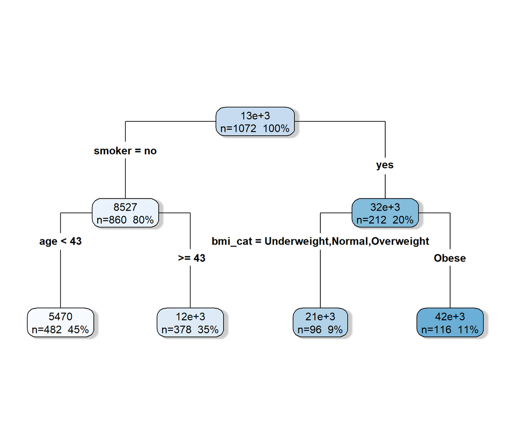

```r
rpart.plot(tree_model, type = 4, extra = 101,
           box.palette = "Blues", shadow.col = "grey80")
```

Reading this tree from the top down:

- The **first split is on smoking status** — immediately confirming it as the dominant cost driver. This is the single variable that most reduces prediction error when used as the first decision rule.
- Among **smokers**, BMI above approximately 30 creates a second tier — obese smokers form the highest-cost subgroup in the entire dataset.
- Among **non-smokers**, age becomes the primary differentiator, with older patients predicting higher costs — consistent with our earlier correlation and scatter plot findings.

The tree makes the interaction between smoking and BMI tangible: the BMI split only appears in the smoker branch, not the non-smoker branch, which is a non-parametric confirmation of the same interaction we detected in the linear model.

```r
tree_pred <- predict(tree_model, test)
rmse_tree <- rmse(test$charges, tree_pred)
```

### Random Forest

A random forest builds hundreds of individual decision trees, each trained on a random subset of the data and a random subset of the predictors, then averages their predictions. This averaging process substantially reduces the variance that makes any single tree unreliable.

We use **10-fold cross-validation** to tune the key hyperparameter `mtry` — the number of predictors considered at each split. Cross-validation works by repeatedly partitioning the training data into 10 chunks, training on 9 and validating on the 10th, rotating through all chunks. This gives a more stable performance estimate than a single split would provide.

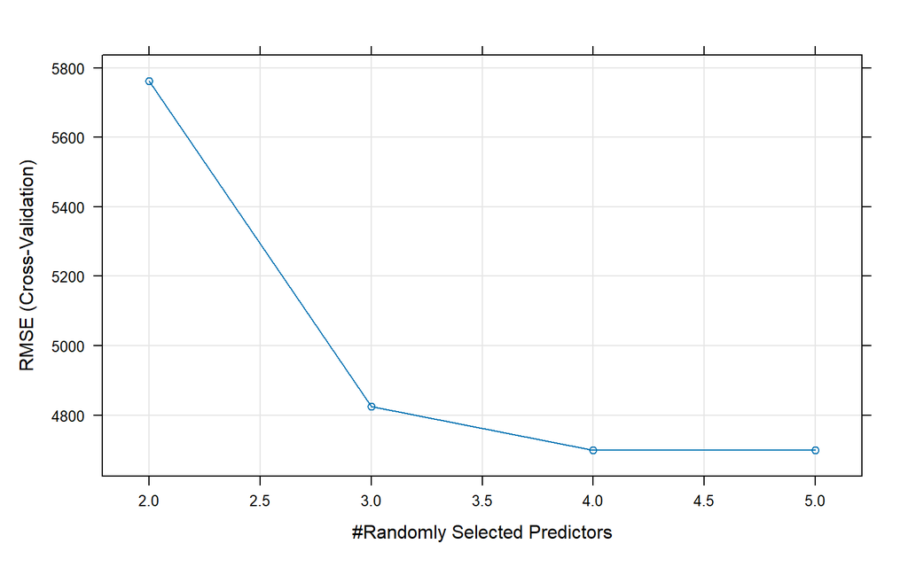

```r
cv_control <- trainControl(method = "cv", number = 10, savePredictions = "final")

rf_cv <- train(
  charges ~ .,
  data      = train,
  method    = "rf",
  trControl = cv_control,
  tuneGrid  = data.frame(mtry = c(2, 3, 4, 5)),
  ntree     = 500
)

plot(rf_cv)
```

The plot shows cross-validated RMSE (prediction error in USD) for each value of `mtry`. Lower is better. We select the `mtry` value that minimises CV-RMSE — the model automatically retains this as the final model.

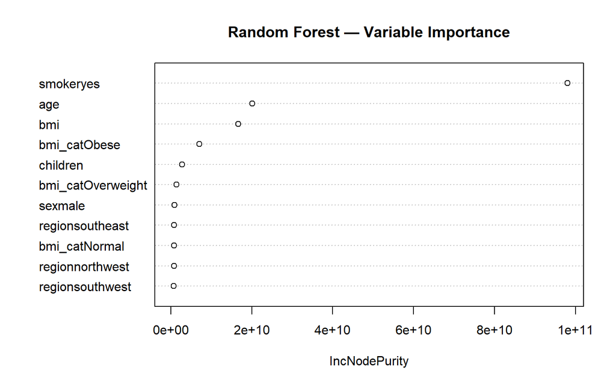

```r
rf_model <- rf_cv$finalModel
rf_pred  <- predict(rf_cv, test)
rmse_rf  <- rmse(test$charges, rf_pred)

varImpPlot(rf_model, main = "Random Forest — Variable Importance")
```

### XGBoost

XGBoost (Extreme Gradient Boosting) builds trees sequentially, where each new tree focuses on correcting the errors made by all previous trees. This makes it highly accurate but less interpretable than a single tree. It is widely used in applied machine learning and often achieves the best predictive performance on tabular data.

```r
x_train <- model.matrix(charges ~ ., data = train)[, -1]
x_test  <- model.matrix(charges ~ ., data = test)[, -1]
y_train <- train$charges

dtrain <- xgb.DMatrix(data = x_train, label = y_train)
dtest  <- xgb.DMatrix(data = x_test,  label = test$charges)

xgb_model <- xgb.train(
  params = list(
    objective        = "reg:squarederror",
    max_depth        = 4,
    eta              = 0.05,
    subsample        = 0.8,
    colsample_bytree = 0.8
  ),
  data                  = dtrain,
  nrounds               = 500,
  watchlist             = list(train = dtrain, eval = dtest),
  early_stopping_rounds = 30,
  print_every_n         = 100,
  verbose               = 1
)
```

```
## Multiple eval metrics are present. Will use eval_rmse for early stopping.
## Will train until eval_rmse hasn't improved in 30 rounds.
##
## Stopping. Best iteration:
##
```

```r
xgb_pred <- predict(xgb_model, dtest)
rmse_xgb <- rmse(test$charges, xgb_pred)
```

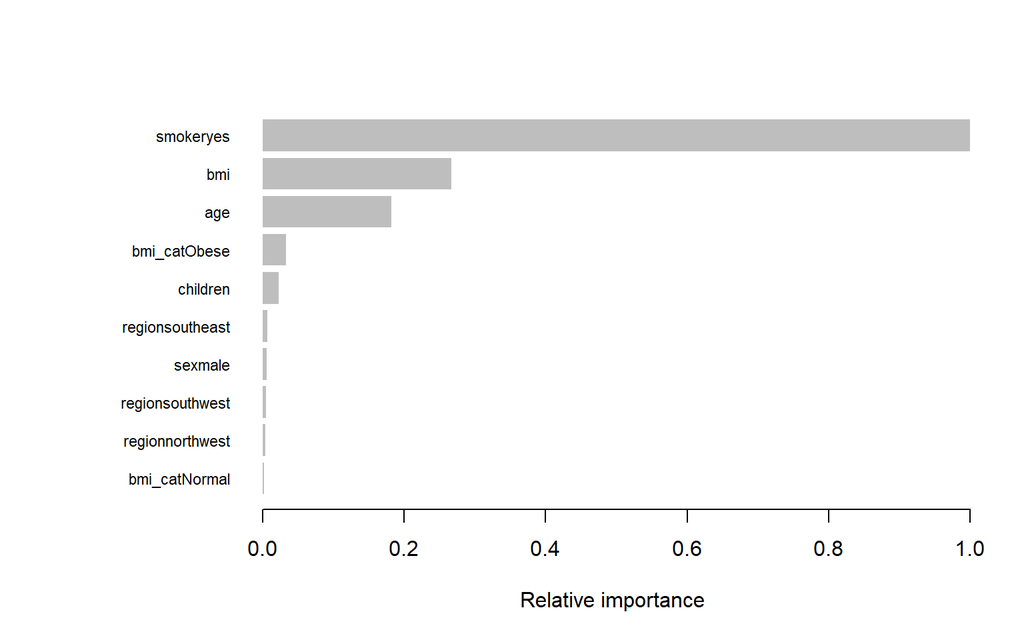

```r
xgb.importance(model = xgb_model) |>
  xgb.plot.importance(top_n = 10, rel_to_first = TRUE,
                      xlab = "Relative importance")
```

XGBoost’s importance rankings largely mirror the random forest’s findings: **smoker status, age, and BMI are the dominant predictors**. The consistency across two fundamentally different modelling approaches strengthens confidence that these are genuine signals in the data and not artefacts of one particular method.

## Model Comparison

```r
rsquared <- function(actual, predicted) {
  1 - sum((actual - predicted)^2) / sum((actual - mean(actual))^2)
}

results <- data.frame(
  Model = c("Linear Regression", "LM + Interaction",
            "Regression Tree", "Random Forest", "XGBoost"),
  RMSE  = round(c(rmse_lm, rmse_lm_int, rmse_tree, rmse_rf, rmse_xgb), 0),
  R2    = round(c(rsquared(test$charges, lm_pred),
                  rsquared(test$charges, lm_pred_int),
                  rsquared(test$charges, tree_pred),
                  rsquared(test$charges, rf_pred),
                  rsquared(test$charges, xgb_pred)), 3)
) |> arrange(RMSE)

print(results)
```

```
##               Model RMSE    R2
## 1           XGBoost 4155 0.884
## 2  LM + Interaction 4244 0.879
## 3     Random Forest 4336 0.873
## 4   Regression Tree 5027 0.830
## 5 Linear Regression 5713 0.780
```

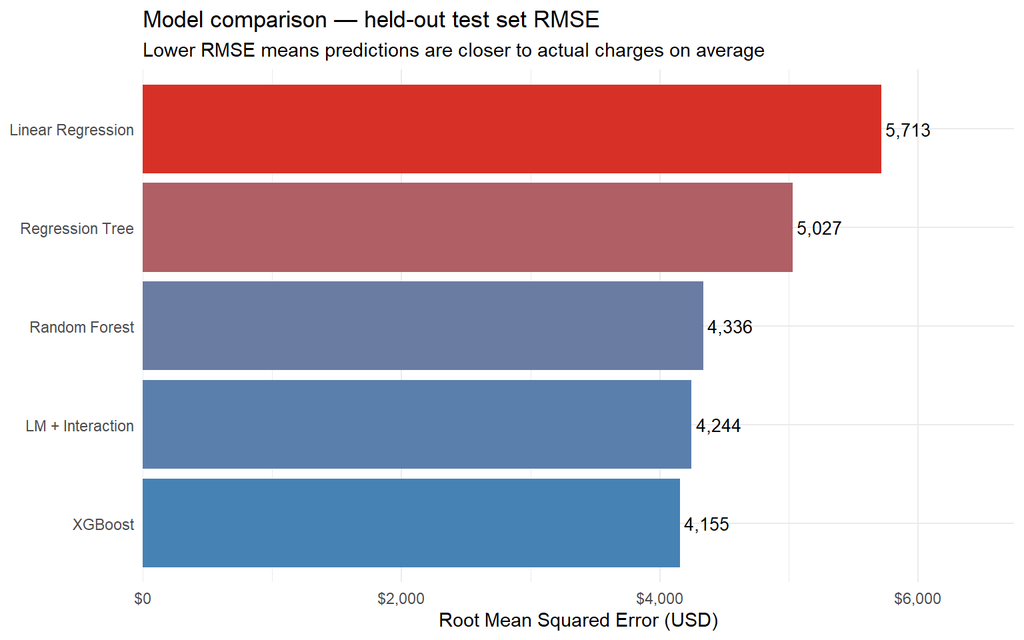

```r
results |>
  ggplot(aes(x = reorder(Model, RMSE), y = RMSE, fill = RMSE)) +
  geom_col() +
  geom_text(aes(label = comma(RMSE)), hjust = -0.1, size = 3.5) +
  coord_flip() +
  scale_fill_gradient(low = "steelblue", high = "#D73027") +
  scale_y_continuous(labels = dollar_format(),
                     expand = expansion(mult = c(0, 0.18))) +
  labs(title = "Model comparison — held-out test set RMSE",
       subtitle = "Lower RMSE means predictions are closer to actual charges on average",
       x = NULL, y = "Root Mean Squared Error (USD)") +
  theme_minimal() +
  theme(legend.position = "none")
```

**RMSE** (Root Mean Squared Error) is the average prediction error in USD — a model with RMSE of $4,000 is wrong by about $4,000 on average. **R²** is the proportion of variance in charges explained by the model — an R² of 0.85 means the model accounts for 85% of the variation in costs across patients.

## Partial Dependence Analysis

The model comparison tells us *how accurate* each model is, but not *how* each predictor influences predictions. Partial dependence plots (PDPs) address this by showing the marginal effect of one predictor after averaging out all the others — essentially asking “if we held everything else constant, what would changing this variable do to predicted costs?”

This is more informative than a raw scatter plot, which confounds the effect of each variable with all others it correlates with.

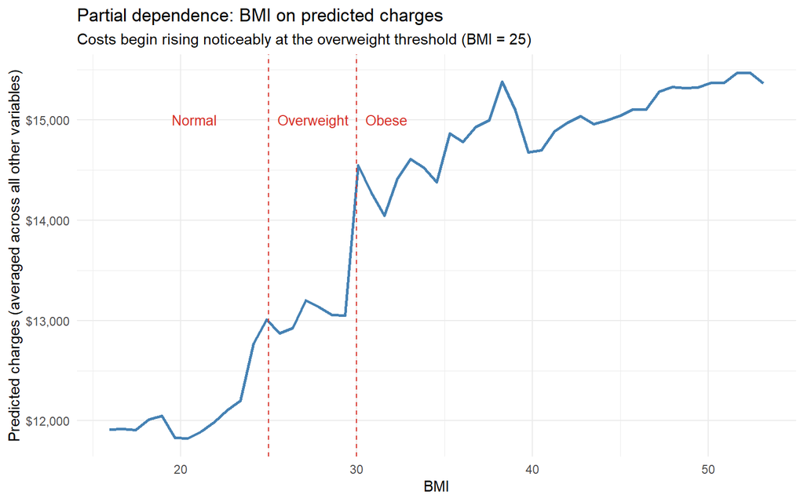

```r
pd_bmi <- partial(rf_cv, pred.var = "bmi", train = train)

pd_bmi |>
  as.data.frame() |>
  ggplot(aes(bmi, yhat)) +
  geom_line(colour = "steelblue", linewidth = 1) +
  geom_vline(xintercept = 25, linetype = "dashed", colour = "#D73027") +
  geom_vline(xintercept = 30, linetype = "dashed", colour = "#D73027") +
  annotate("text", x = 19.5, y = max(pd_bmi$yhat) * 0.97,
           label = "Normal", hjust = 0, colour = "#D73027", size = 3.5) +
  annotate("text", x = 25.5, y = max(pd_bmi$yhat) * 0.97,
           label = "Overweight", hjust = 0, colour = "#D73027", size = 3.5) +
  annotate("text", x = 30.5, y = max(pd_bmi$yhat) * 0.97,
           label = "Obese", hjust = 0, colour = "#D73027", size = 3.5) +
  scale_y_continuous(labels = dollar_format()) +
  labs(title    = "Partial dependence: BMI on predicted charges",
       subtitle = "Costs begin rising noticeably at the overweight threshold (BMI = 25)",
       x = "BMI", y = "Predicted charges (averaged across all other variables)") +
  theme_minimal()
```

The BMI curve is not a straight line — costs are relatively stable in the normal weight range then begin increasing from the overweight threshold (BMI ≥ 25), accelerating through the obese range (BMI ≥ 30). This non-linear pattern would not be captured by a linear model without explicit polynomial terms, but the random forest detects it automatically.

**Policy implication**: weight management interventions that move patients even from the obese to overweight category — not necessarily to a “healthy” weight — could yield meaningful cost reductions, suggesting intermediate targets may be achievable and worth pursuing.

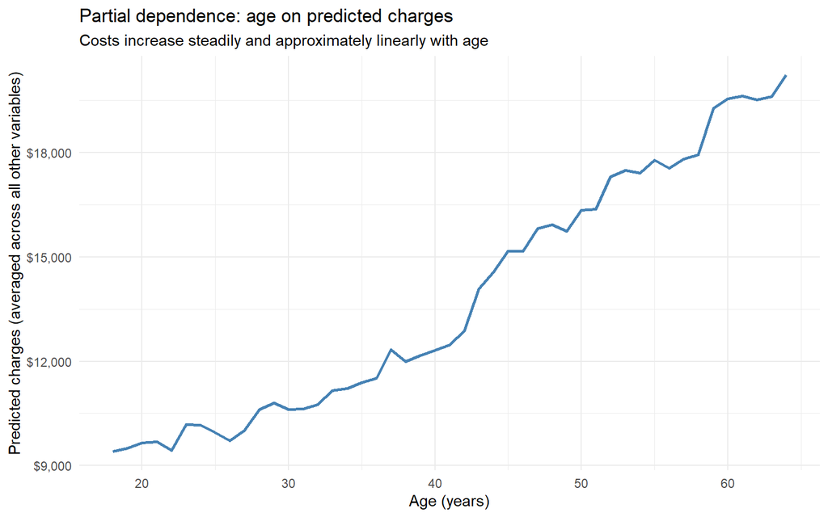

```r
pd_age <- partial(rf_cv, pred.var = "age", train = train)

pd_age |>
  as.data.frame() |>
  ggplot(aes(age, yhat)) +
  geom_line(colour = "steelblue", linewidth = 1) +
  scale_y_continuous(labels = dollar_format()) +
  labs(title    = "Partial dependence: age on predicted charges",
       subtitle = "Costs increase steadily and approximately linearly with age",
       x = "Age (years)", y = "Predicted charges (averaged across all other variables)") +
  theme_minimal()
```

Age is not a modifiable risk factor, but it is useful for **risk stratification** — identifying older patients for preventive screening or early intervention programmes that address the *modifiable* factors (smoking, BMI) before costs escalate.

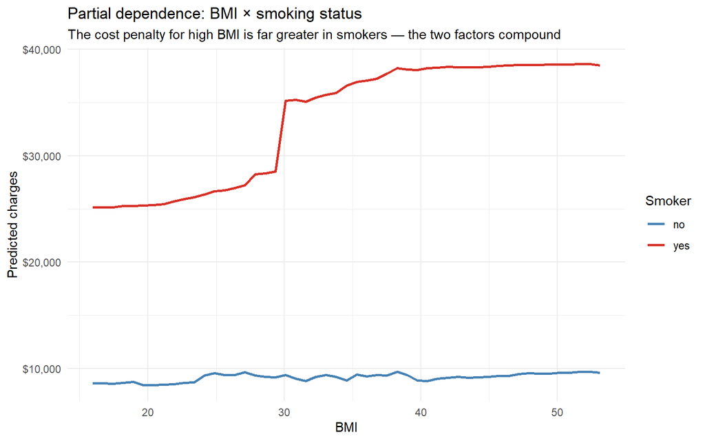

```r
partial(rf_cv, pred.var = c("bmi", "smoker"), train = train) |>
  as.data.frame() |>
  ggplot(aes(bmi, yhat, colour = smoker)) +
  geom_line(linewidth = 1) +
  scale_y_continuous(labels = dollar_format()) +
  scale_colour_manual(values = c("no" = "steelblue", "yes" = "#D73027")) +
  labs(title    = "Partial dependence: BMI × smoking status",
       subtitle = "The cost penalty for high BMI is far greater in smokers — the two factors compound",
       x = "BMI", y = "Predicted charges", colour = "Smoker") +
  theme_minimal()
```

This is the most important plot in the analysis. It shows directly that:

- For **non-smokers**, BMI has a modest effect on costs across most of the range.
- For **smokers**, higher BMI produces dramatically higher costs, and the gap widens as BMI increases.

This interaction means that a smoker with obesity (BMI ≥ 30) does not simply pay the “smoker penalty” plus the “obesity penalty” as two separate amounts — the combination is *worse than the sum of the parts*. A public health programme targeting both smoking cessation and weight management simultaneously in high-BMI smokers would address the highest-cost subgroup in this dataset.

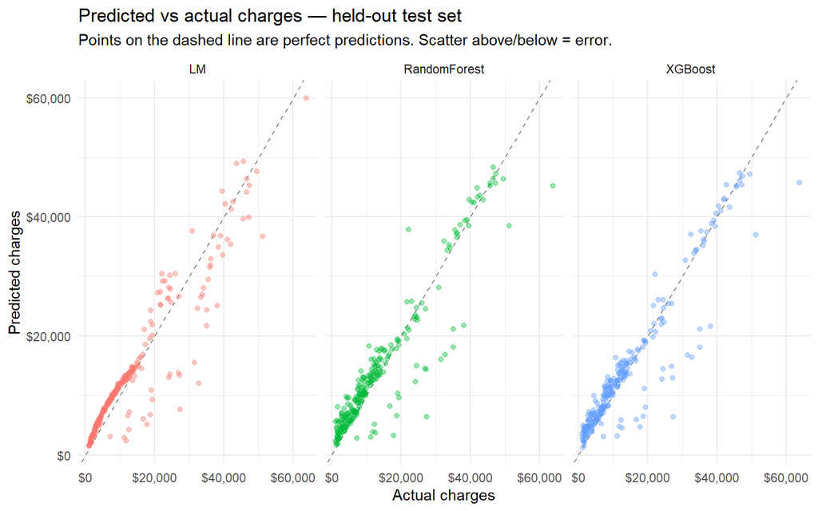

```r
data.frame(
  actual       = test$charges,
  LM           = lm_pred_int,
  RandomForest = rf_pred,
  XGBoost      = xgb_pred
) |>
  pivot_longer(-actual, names_to = "model", values_to = "predicted") |>
  ggplot(aes(x = actual, y = predicted, colour = model)) +
  geom_abline(slope = 1, intercept = 0, linetype = "dashed", colour = "grey40") +
  geom_point(alpha = 0.4, size = 1.5) +
  facet_wrap(~ model) +
  scale_x_continuous(labels = dollar_format()) +
  scale_y_continuous(labels = dollar_format()) +
  labs(title    = "Predicted vs actual charges — held-out test set",
       subtitle = "Points on the dashed line are perfect predictions. Scatter above/below = error.",
       x = "Actual charges", y = "Predicted charges") +
  theme_minimal() +
  theme(legend.position = "none")
```

These plots reveal *where* each model fails, not just how much:

- The **linear model** shows a clear curved pattern — it systematically underpredicts very high costs and overpredicts some low-cost patients. This reflects the non-linearities the model cannot capture.
- **Random Forest and XGBoost** track the diagonal more closely across the full range, though both still show some scatter at the high end — extreme-cost patients are inherently difficult to predict precisely.

## Public Health Interpretation

### Summary of findings

Three consistent findings emerge across all modelling approaches, from the simplest correlation to the most complex ensemble:

**1. Smoking is the single largest modifiable driver of healthcare costs.** Smokers pay substantially more than non-smokers, and this premium compounds with BMI. At the average BMI in this dataset, a smoker pays approximately the amount calculated earlier per year in additional charges. This is not a marginal effect — it is the dominant signal in the data.

**2. The combination of smoking and obesity creates a disproportionately high-cost subgroup.** This interaction effect appeared in the linear model’s formal significance test, in the regression tree’s first two splits, in the random forest’s variable importance rankings, and in the partial dependence plots. Agreement across all four methods means this finding is robust. Obese smokers are not just the sum of two risk factors — they are a distinct, high-cost group.

**3. Age increases costs steadily but is not interactive with other factors.** Unlike BMI, the age effect does not depend on smoking status. Age is non-modifiable, but it is a useful tool for risk stratification — identifying older patients who also smoke or have high BMI, and prioritising them for preventive intervention, would target resources at the highest-cost individuals.

### What this means for policy

If the goal is to reduce population-level healthcare costs, this analysis suggests three prioritised actions:

1. **Smoking cessation programmes** — particularly those targeting people who are also overweight or obese. The interaction effect means the cost return on helping a high-BMI smoker quit is substantially larger than helping a normal-weight smoker quit.
2. **Weight management support for people who smoke** — even modest reductions in BMI within the smoker subgroup are associated with meaningful cost reductions, due to the steep slope of the BMI-cost curve for this group.
3. **Age-based risk stratification** — using age as a flag to identify patients for preventive screening and behavioural health support before costs escalate. Age alone cannot be addressed, but it reliably identifies patients where addressing modifiable factors (smoking, BMI) would have the greatest expected impact.

Sex and region had weak independent effects after other factors were controlled for. Policy resources focused on geography or sex-specific programmes would likely produce smaller returns than those targeting the behavioural factors above.

### Limitations

- This is a **US insurance dataset** with a specific demographic and coverage structure. Direct quantitative translation to Australian public health costs (e.g. NSW Health) would require Australian data, though the directional findings are consistent with clinical evidence globally.
- The dataset is relatively small (n = 1,338). Confidence intervals around cost estimates are correspondingly wide — the exact dollar figures should be treated as indicative rather than precise.
- The linear model’s assumption violations (heteroscedasticity, non-normality of residuals) mean the reported p-values and confidence intervals are approximations. Key conclusions were cross-validated against tree-based methods that do not share these assumptions, providing additional confidence in the findings.
- This analysis is **observational** — we cannot claim that smoking or obesity *causes* higher charges from this data alone, only that they are strongly associated. Causal interpretation requires experimental design or longitudinal data with appropriate confounding adjustment.